# Applied Probability and Statistics II Projects

# Project 1

## Problem 1

### 1

dbinom: the binomial distribution of a vector. pbinom: the cumulative distribution of a vector. barplot: Creates a bar plot with vertical or horizontal bars.

### 2

#### Plot 1:

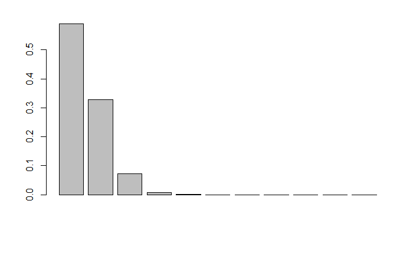

```r
barplot(dbinom(0:10, 5, .1))
```

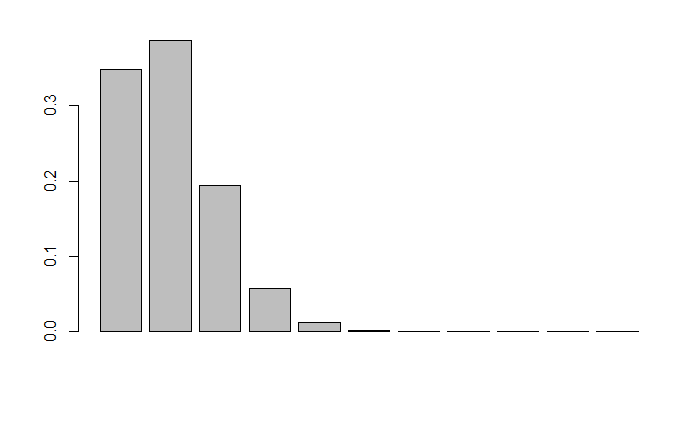

```r
barplot(dbinom(0:10, 10, .1))
```

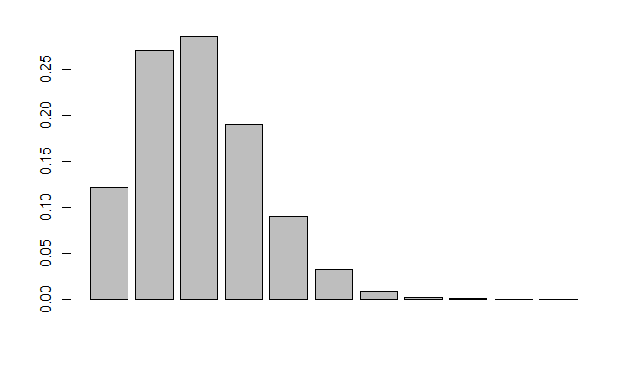

```r
barplot(dbinom(0:10, 20, .1))
```

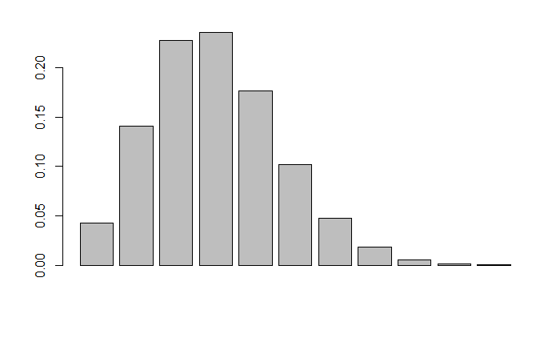

```r
barplot(dbinom(0:10, 30, .1))
```

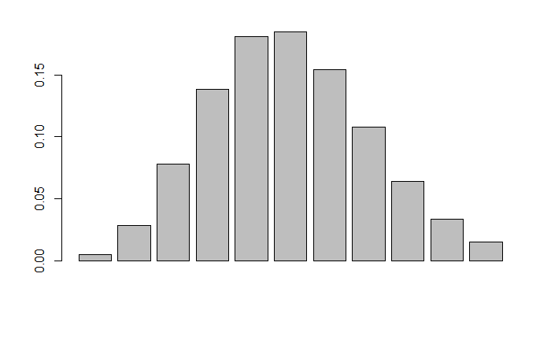

```r
barplot(dbinom(0:10, 50, .1))
```

#### Plot 2:

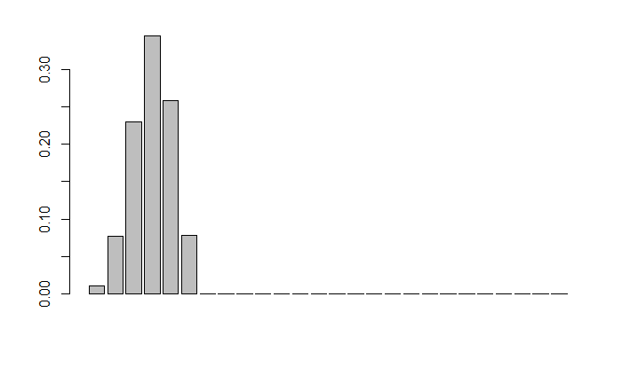

```r
barplot(dbinom(0:25, 5, .6))
```

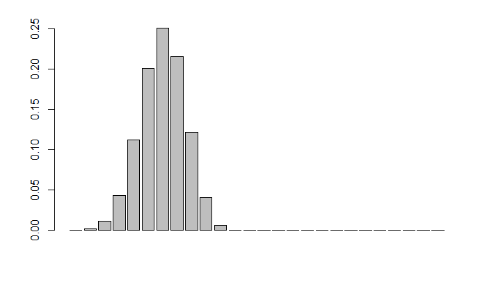

```r
barplot(dbinom(0:25, 10, .6))
```

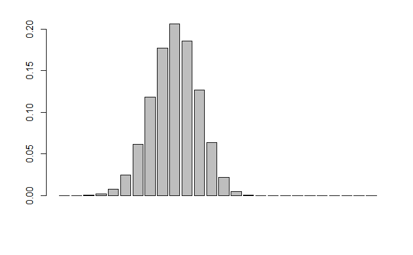

```r
barplot(dbinom(0:25, 15, .6))
```

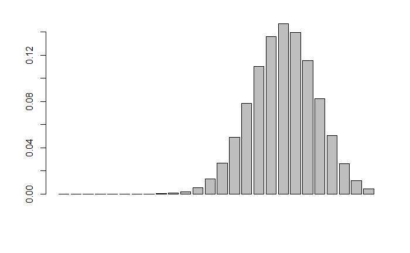

```r
barplot(dbinom(0:25, 30, .6))
```

#### Plot 3:

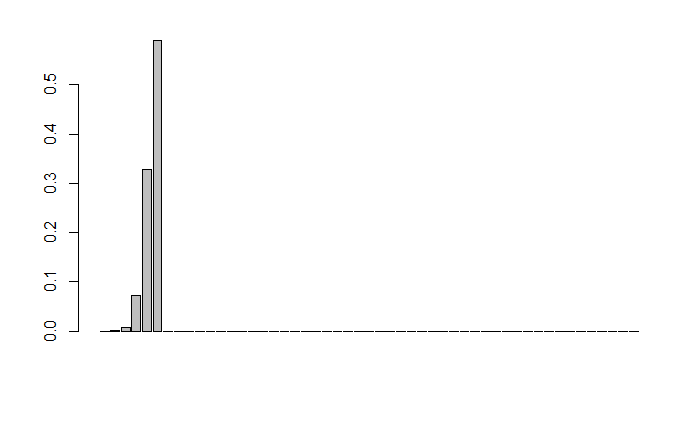

```r
barplot(dbinom(0:50, 5, .9))
```

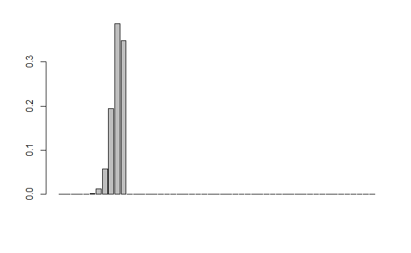

```r
barplot(dbinom(0:50, 10, .9))
```

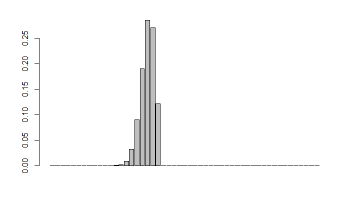

```r
barplot(dbinom(0:50, 20, .9))
```

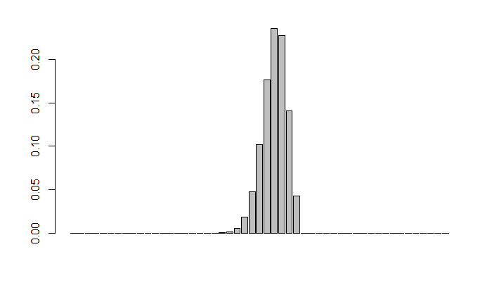

```r
barplot(dbinom(0:50, 30, .9))
```

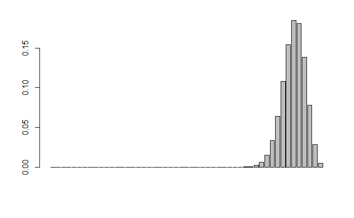

```r
barplot(dbinom(0:50, 50, .9))
```

### 3

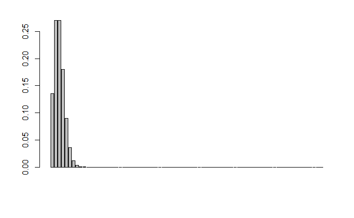

```r
lambda <- c(2,4,5,10,20,30,50)
barplot(dpois(0:75,2))
```

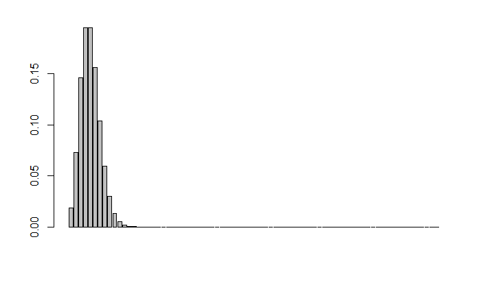

```r
barplot(dpois(0:75,4))
```

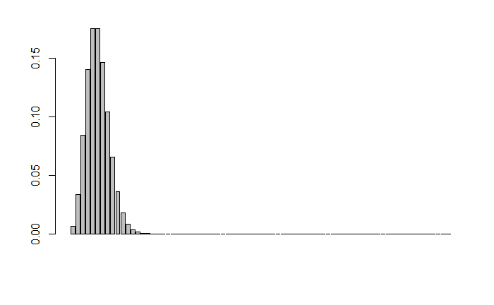

```r
barplot(dpois(0:75,5))
```

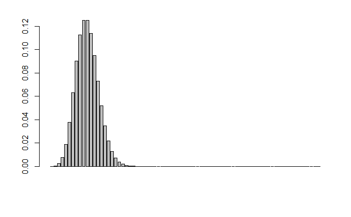

```r
barplot(dpois(0:75,10))
```

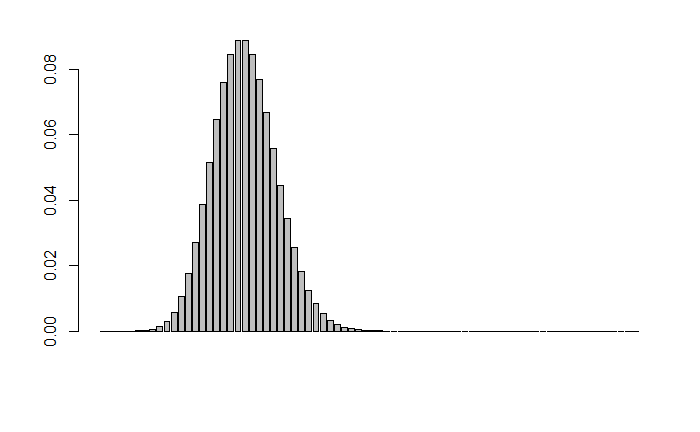

```r
barplot(dpois(0:75,20))
```

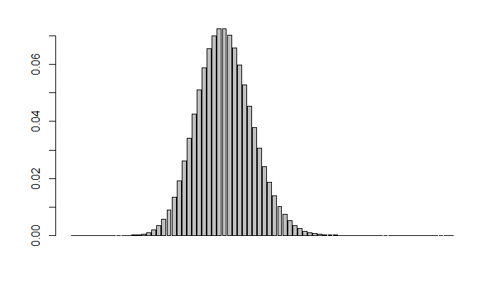

```r
barplot(dpois(0:75,30))
```

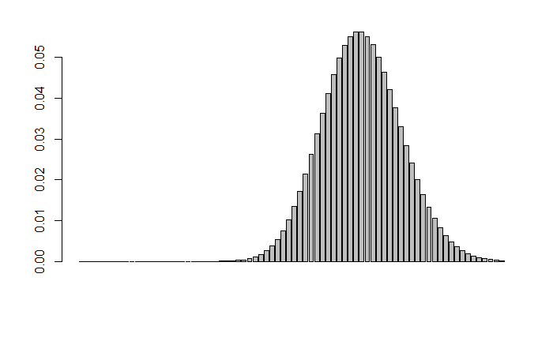

```r
barplot(dpois(0:75,50))
```

### 4

The Poisson distribution looks more like a normal distribution at higher lambdas.

## Problem 2

### 1

```r
x <- c(2, 4, 6, 10)
p_x <- c(.3, .35, .25, .1)
E_x <- 0
for(i in seq_along(x)){
  a <- x[i]*p_x[i]
  E_x <<- E_x + a
}
paste0("Expected Value = ", E_x)
```

```
[1] "Expected Value = 4.5"
```

### 2

```r
x <- c(2, 4, 6, 10)
p_x <- c(.3, .35, .25, .1)
E_x2 <- 0
for(i in seq_along(x)){
  a <- (x[i])^2*p_x[i]
  E_x2 <<- E_x2 + a
}
sigma <- sqrt(E_x2 - (E_x)^2)
paste0("Standard Deviation = ", sigma)
```

```
[1] "Standard Deviation = 2.35584379787795"
```

### 3

```r
#n <- c(2, 6, 12, 20, 100, 150)
B <- 8000
sale <- function(){
 a <- sample(1:100)
 if(1 <= a && a <= 30){
   price <<- 2
}
 if(31 <= a && a <= 65){
   price <<- 4
}
 if(66 <= a && a <= 90){
   price <<- 6
}
 if(91 <= a && a <= 100){
   price <<- 10
 }
 # print(price)
}

total_sales <- function(n){
  total_price <<- 0
  for(i in 1:n){
    sale()
    total_price <<- total_price + price
  }
  # print(total_price)
  ave_sales <- total_price/n
  return(ave_sales)
}

n_2 <- replicate(B, total_sales(2))
paste0("Average Revenue for 2 pens sold = ", mean(n_2))
```

```
[1] "Average Revenue for 2 pens sold = 4.5205"
```

```r
n_6 <- replicate(B, total_sales(6))
paste0("Average Revenue for 6 pens sold = ", mean(n_6))
```

```
[1] "Average Revenue for 6 pens sold = 4.484375"
```

```r
n_12 <- replicate(B, total_sales(12))
paste0("Average Revenue for 12 pens sold = ", mean(n_12))
```

```
[1] "Average Revenue for 12 pens sold = 4.50354166666667"
```

```r
n_20 <- replicate(B, total_sales(20))
paste0("Average Revenue for 20 pens sold = ", mean(n_20))
```

```
[1] "Average Revenue for 20 pens sold = 4.51235"
```

```r
n_100 <- replicate(B, total_sales(100))
paste0("Average Revenue for 100 pens sold = ", mean(n_100))
```

```
[1] "Average Revenue for 100 pens sold = 4.50075"
```

```r
n_150 <- replicate(B, total_sales(150))
paste0("Average Revenue for 150 pens sold = ", mean(n_150))
```

```
[1] "Average Revenue for 150 pens sold = 4.496935"
```

### 4

#### a

```r
distribution_X_bar <- function(a){
amount <- rep(0, 10)
a <- round(a, digits = 0)
for(i in 1:8000){
  amount[a[i]] <- amount[a[i]] + 1
}
print(amount)
}

paste0("   1   2    3   4    5     6    7    8     9   10")
```

```
[1] "   1   2    3   4    5     6    7    8     9   10"
```

```r
distribution_X_bar(n_2)
```

```
 [1]    0  724 1685 2155 1384  958  561  442    0   91
```

```r
distribution_X_bar(n_6)
```

```
 [1]    0   38 1150 3086 2570  940  198   14    4    0
```

```r
distribution_X_bar(n_12)
```

```
 [1]    0    4  358 4193 2676  752   17    0    0    0
```

```r
distribution_X_bar(n_20)
```

```
 [1]    0    0  107 4264 3295  332    2    0    0    0
```

```r
distribution_X_bar(n_100)
```

```
 [1]    0    0    0 4152 3848    0    0    0    0    0
```

```r
distribution_X_bar(n_150)
```

```
 [1]    0    0    0 4082 3918    0    0    0    0    0
```

#### b

```r
print(paste0("Expected value for n = 2: ", mean(n_2)))
```

```
[1] "Expected value for n = 2: 4.5205"
```

```r
print(paste0("Expected value for n = 6: ", mean(n_6)))
```

```
[1] "Expected value for n = 6: 4.484375"
```

```r
print(paste0("Expected value for n = 12: ", mean(n_12)))
```

```
[1] "Expected value for n = 12: 4.50354166666667"
```

```r
print(paste0("Expected value for n = 20: ", mean(n_20)))
```

```
[1] "Expected value for n = 20: 4.51235"
```

```r
print(paste0("Expected value for n = 100: ", mean(n_100)))
```

```
[1] "Expected value for n = 100: 4.50075"
```

```r
print(paste0("Expected value for n = 150: ", mean(n_150)))
```

```
[1] "Expected value for n = 150: 4.496935"
```

```r
print(paste0("Standard Deviation for n = 2: ", sd(n_2)))
```

```
[1] "Standard Deviation for n = 2: 1.69667014655126"
```

```r
print(paste0("Standard Deviation for n = 6: ", sd(n_6)))
```

```
[1] "Standard Deviation for n = 6: 0.954758738818668"
```

```r
print(paste0("Standard Deviation for n = 12: ", sd(n_12)))
```

```
[1] "Standard Deviation for n = 12: 0.67889559997716"
```

```r
print(paste0("Standard Deviation for n = 20: ", sd(n_20)))
```

```
[1] "Standard Deviation for n = 20: 0.521117954968329"
```

```r
print(paste0("Standard Deviation for n = 100: ", sd(n_100)))
```

```
[1] "Standard Deviation for n = 100: 0.234908354985312"
```

```r
print(paste0("Standard Deviation for n = 150: ", sd(n_150)))
```

```
[1] "Standard Deviation for n = 150: 0.193497623721178"
```

#### c

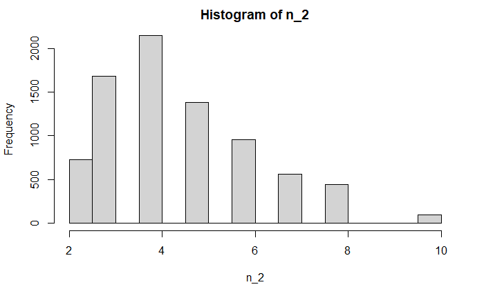

```r
hist(n_2)
```

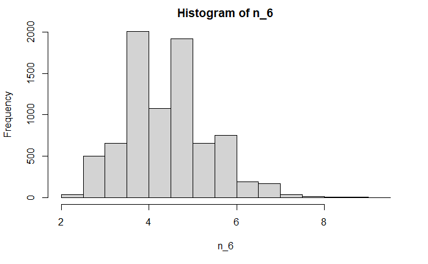

```r
hist(n_6)
```

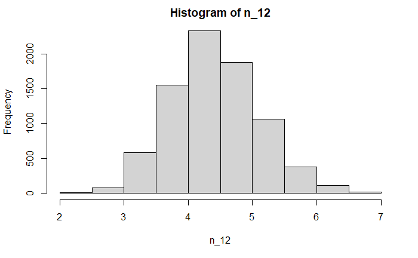

```r
hist(n_12)
```

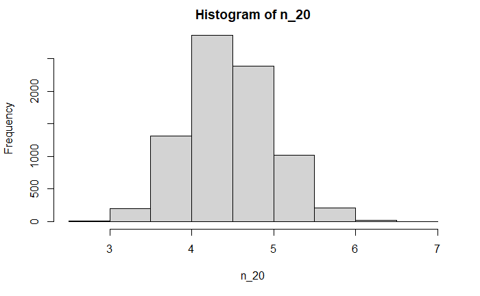

```r
hist(n_20)
```

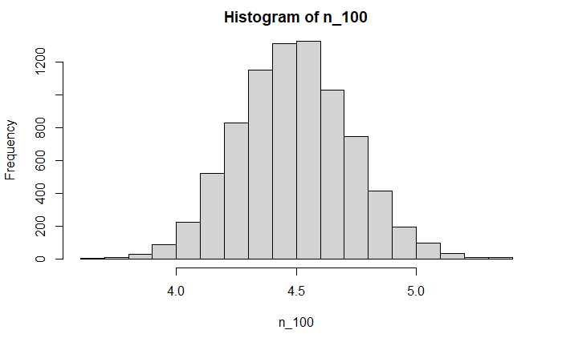

```r
hist(n_100)
```

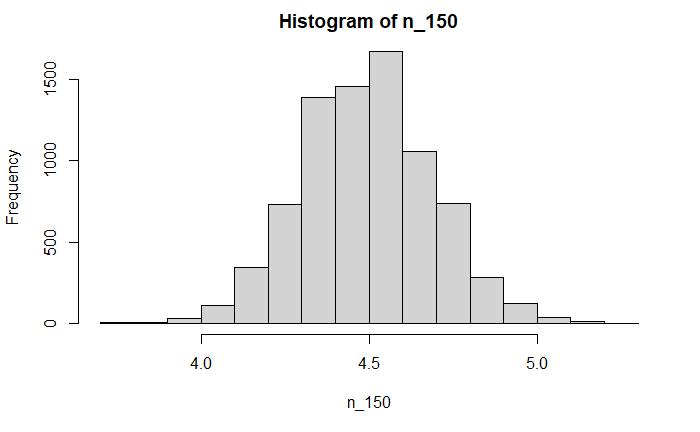

```r
hist(n_150)
```

#### d

```r
n_15_3000 <- replicate(3000, total_sales(15))
n_25_3000 <- replicate(3000, total_sales(25))
n_1_3000 <- replicate(3000, total_sales(1))
n_1_5 <- replicate(5, total_sales(1))

print(mean(n_15_3000))
```

```
[1] 4.518133
```

```r
print(mean(n_25_3000))
```

```
[1] 4.499413
```

```r
print(mean(n_1_3000))
```

```
[1] 4.514667
```

```r
print(mean(n_1_5))
```

```
[1] 5.2
```

#### e

This experiment definitely shows how Central Limit Theorem comes into play. If you look at the histograms, the distribution definitely looks more normal as n increases, with the exception of n = 100 looking more normal than n = 150. However, CLT gives us normal distribution as an approximation so it’s not going to be perfect. Also, when you see the total sales is 1 and only 5 replications, you can see how these lower numbers gave us a sample mean much farther off from the expected value calculated at the beginning of the problem when contrasted with higher replications and a higher n.

## Problem 3

### 1

```r
B <- 10000

normal_5 <- replicate(B, rnorm(5, mean = 10, sd = 2))
normal_10 <- replicate(B, rnorm(10, mean = 10, sd = 2))
normal_15 <- replicate(B, rnorm(15, mean = 10, sd = 2))
normal_25 <- replicate(B, rnorm(25, mean = 10, sd = 2))
normal_30 <- replicate(B, rnorm(30, mean = 10, sd = 2))
normal_50 <- replicate(B, rnorm(50, mean = 10, sd = 2))
normal_100 <- replicate(B, rnorm(100, mean = 10, sd = 2))

print(paste0("Expected value for n = 5: ", mean(normal_5)))
```

```
[1] "Expected value for n = 5: 10.0050249942125"
```

```r
print(paste0("Expected value for n = 10: ", mean(normal_10)))
```

```
[1] "Expected value for n = 10: 10.0198995350932"
```

```r
print(paste0("Expected value for n = 15: ", mean(normal_15)))
```

```
[1] "Expected value for n = 15: 9.99303422942158"
```

```r
print(paste0("Expected value for n = 25: ", mean(normal_25)))
```

```
[1] "Expected value for n = 25: 9.99389890431309"
```

```r
print(paste0("Expected value for n = 30: ", mean(normal_30)))
```

```
[1] "Expected value for n = 30: 10.001683837959"
```

```r
print(paste0("Expected value for n = 50: ", mean(normal_50)))
```

```
[1] "Expected value for n = 50: 9.9957677111114"
```

```r
print(paste0("Expected value for n = 100: ", mean(normal_100)))
```

```
[1] "Expected value for n = 100: 9.99859979976599"
```

```r
print(paste0("Standard deviation for n = 5: ", sd(normal_5)))
```

```
[1] "Standard deviation for n = 5: 2.00504820428661"
```

```r
print(paste0("Standard deviation for n = 10: ", sd(normal_10)))
```

```
[1] "Standard deviation for n = 10: 2.00186414577681"
```

```r
print(paste0("Standard deviation for n = 15: ", sd(normal_15)))
```

```
[1] "Standard deviation for n = 15: 2.00158200857388"
```

```r
print(paste0("Standard deviation for n = 25: ", sd(normal_25)))
```

```
[1] "Standard deviation for n = 25: 1.99643853318638"
```

```r
print(paste0("Standard deviation for n = 30: ", sd(normal_30)))
```

```
[1] "Standard deviation for n = 30: 1.99939728370864"
```

```r
print(paste0("Standard deviation for n = 50: ", sd(normal_50)))
```

```
[1] "Standard deviation for n = 50: 2.00356929052791"
```

```r
print(paste0("Standard deviation for n = 100: ", sd(normal_100)))
```

```
[1] "Standard deviation for n = 100: 1.9997722153665"
```

```r
writeLines("\n")
```

```r
CLTN_5 <- replicate(B, rnorm(5, mean = 10, sd = 2/sqrt(5)))
CLTN_10 <- replicate(B, rnorm(10, mean = 10, sd = 2/sqrt(10)))
CLTN_15 <- replicate(B, rnorm(15, mean = 10, sd = 2/sqrt(15)))
CLTN_25 <- replicate(B, rnorm(25, mean = 10, sd = 2/sqrt(25)))
CLTN_30 <- replicate(B, rnorm(30, mean = 10, sd = 2/sqrt(30)))
CLTN_50 <- replicate(B, rnorm(50, mean = 10, sd = 2/sqrt(50)))
CLTN_100 <- replicate(B, rnorm(100, mean = 10, sd = 2/sqrt(100)))

print(paste0("For the CLT Approximation for the normal distribution with mu = 10 and sigma = 2:"))
```

```
[1] "For the CLT Approximation for the normal distribution with mu = 10 and sigma = 2:"
```

```r
print(paste0("Expected value for n = 5: ", mean(CLTN_5)))
```

```
[1] "Expected value for n = 5: 10.0009734911606"
```

```r
print(paste0("Expected value for n = 10: ", mean(CLTN_10)))
```

```
[1] "Expected value for n = 10: 10.0004648729649"
```

```r
print(paste0("Expected value for n = 15: ", mean(CLTN_15)))
```

```
[1] "Expected value for n = 15: 9.99834078010144"
```

```r
print(paste0("Expected value for n = 25: ", mean(CLTN_25)))
```

```
[1] "Expected value for n = 25: 10.000033447347"
```

```r
print(paste0("Expected value for n = 30: ", mean(CLTN_30)))
```

```
[1] "Expected value for n = 30: 10.0001081593825"
```

```r
print(paste0("Expected value for n = 50: ", mean(CLTN_50)))
```

```
[1] "Expected value for n = 50: 10.0001769563096"
```

```r
print(paste0("Expected value for n = 100: ", mean(CLTN_100)))
```

```
[1] "Expected value for n = 100: 9.99984731931502"
```

```r
print(paste0("Standard deviation for n = 5: ", sd(CLTN_5)))
```

```
[1] "Standard deviation for n = 5: 0.895849552390686"
```

```r
print(paste0("Standard deviation for n = 10: ", sd(CLTN_10)))
```

```
[1] "Standard deviation for n = 10: 0.632473652422243"
```

```r
print(paste0("Standard deviation for n = 15: ", sd(CLTN_15)))
```

```
[1] "Standard deviation for n = 15: 0.515461381406866"
```

```r
print(paste0("Standard deviation for n = 25: ", sd(CLTN_25)))
```

```
[1] "Standard deviation for n = 25: 0.400694375350025"
```

```r
print(paste0("Standard deviation for n = 30: ", sd(CLTN_30)))
```

```
[1] "Standard deviation for n = 30: 0.365269570103565"
```

```r
print(paste0("Standard deviation for n = 50: ", sd(CLTN_50)))
```

```
[1] "Standard deviation for n = 50: 0.282372472833309"
```

```r
print(paste0("Standard deviation for n = 100: ", sd(CLTN_100)))
```

```
[1] "Standard deviation for n = 100: 0.200032689168696"
```

### 2

```r
exp_5 <- replicate(10000, rexp(5, 2))
exp_10 <- replicate(10000, rexp(10, 2))
exp_15 <- replicate(10000, rexp(15, 2))
exp_25 <- replicate(10000, rexp(25, 2))
exp_30 <- replicate(10000, rexp(30, 2))
exp_50 <- replicate(10000, rexp(50, 2))
exp_100 <- replicate(10000, rexp(100, 2))

print(paste0("For the exponential distribution with lambda = 2:"))
```

```
[1] "For the exponential distribution with lambda = 2:"
```

```r
print(paste0("Expected value for n = 5: ", mean(exp_5)))
```

```
[1] "Expected value for n = 5: 0.501180239361226"
```

```r
print(paste0("Expected value for n = 10: ", mean(exp_10)))
```

```
[1] "Expected value for n = 10: 0.500643074365096"
```

```r
print(paste0("Expected value for n = 15: ", mean(exp_15)))
```

```
[1] "Expected value for n = 15: 0.500339061892709"
```

```r
print(paste0("Expected value for n = 25: ", mean(exp_25)))
```

```
[1] "Expected value for n = 25: 0.499788559850296"
```

```r
print(paste0("Expected value for n = 30: ", mean(exp_30)))
```

```
[1] "Expected value for n = 30: 0.501195016732483"
```

```r
print(paste0("Expected value for n = 50: ", mean(exp_50)))
```

```
[1] "Expected value for n = 50: 0.499742304218794"
```

```r
print(paste0("Expected value for n = 100: ", mean(exp_100)))
```

```
[1] "Expected value for n = 100: 0.500505794087472"
```

```r
print(paste0("Standard deviation for n = 5: ", sd(exp_5)))
```

```
[1] "Standard deviation for n = 5: 0.497713959070255"
```

```r
print(paste0("Standard deviation for n = 10: ", sd(exp_10)))
```

```
[1] "Standard deviation for n = 10: 0.500092501229133"
```

```r
print(paste0("Standard deviation for n = 15: ", sd(exp_15)))
```

```
[1] "Standard deviation for n = 15: 0.499676691917799"
```

```r
print(paste0("Standard deviation for n = 25: ", sd(exp_25)))
```

```
[1] "Standard deviation for n = 25: 0.500017495877164"
```

```r
print(paste0("Standard deviation for n = 30: ", sd(exp_30)))
```

```
[1] "Standard deviation for n = 30: 0.501226894477538"
```

```r
print(paste0("Standard deviation for n = 50: ", sd(exp_50)))
```

```
[1] "Standard deviation for n = 50: 0.499474290181964"
```

```r
print(paste0("Standard deviation for n = 100: ", sd(exp_100)))
```

```
[1] "Standard deviation for n = 100: 0.499606701937133"
```

```r
writeLines("\n")
```

```r
CLT_5 <- replicate(10000, rnorm(5, .5, .5/sqrt(5)))
CLT_10 <- replicate(10000, rnorm(10, .5, .5/sqrt(10)))
CLT_15 <- replicate(10000, rnorm(15, .5, .5/sqrt(15)))
CLT_25 <- replicate(10000, rnorm(25, .5, .5/sqrt(25)))
CLT_30 <- replicate(10000, rnorm(30, .5, .5/sqrt(30)))
CLT_50 <- replicate(10000, rnorm(50, .5, .5/sqrt(50)))
CLT_100 <- replicate(10000, rnorm(100, .5, .5/sqrt(100)))

print(paste0("For the CLT Approximation for the exponential distribution with lambda = 2:"))
```

```
[1] "For the CLT Approximation for the exponential distribution with lambda = 2:"
```

```r
print(paste0("Expected value for n = 5: ", mean(CLT_5)))
```

```
[1] "Expected value for n = 5: 0.500427881983947"
```

```r
print(paste0("Expected value for n = 10: ", mean(CLT_10)))
```

```
[1] "Expected value for n = 10: 0.500153901717243"
```

```r
print(paste0("Expected value for n = 15: ", mean(CLT_15)))
```

```
[1] "Expected value for n = 15: 0.499842352886824"
```

```r
print(paste0("Expected value for n = 25: ", mean(CLT_25)))
```

```
[1] "Expected value for n = 25: 0.499907615380426"
```

```r
print(paste0("Expected value for n = 30: ", mean(CLT_30)))
```

```
[1] "Expected value for n = 30: 0.500152501852461"
```

```r
print(paste0("Expected value for n = 50: ", mean(CLT_50)))
```

```
[1] "Expected value for n = 50: 0.500072786726881"
```

```r
print(paste0("Expected value for n = 100: ", mean(CLT_100)))
```

```
[1] "Expected value for n = 100: 0.499953113626248"
```

```r
print(paste0("Standard deviation for n = 5: ", sd(CLT_5)))
```

```
[1] "Standard deviation for n = 5: 0.224356251542729"
```

```r
print(paste0("Standard deviation for n = 10: ", sd(CLT_10)))
```

```
[1] "Standard deviation for n = 10: 0.158181222439975"
```

```r
print(paste0("Standard deviation for n = 15: ", sd(CLT_15)))
```

```
[1] "Standard deviation for n = 15: 0.129362750993339"
```

```r
print(paste0("Standard deviation for n = 25: ", sd(CLT_25)))
```

```
[1] "Standard deviation for n = 25: 0.100223119150717"
```

```r
print(paste0("Standard deviation for n = 30: ", sd(CLT_30)))
```

```
[1] "Standard deviation for n = 30: 0.0913299416852787"
```

```r
print(paste0("Standard deviation for n = 50: ", sd(CLT_50)))
```

```
[1] "Standard deviation for n = 50: 0.07069128114044"
```

```r
print(paste0("Standard deviation for n = 100: ", sd(CLT_100)))
```

```
[1] "Standard deviation for n = 100: 0.0499948670128781"
```

### 3

```r
gamma_5 <- replicate(10000, rgamma(5, 2, 1/3))
gamma_10 <- replicate(10000, rgamma(10, 2, 1/3))
gamma_15 <- replicate(10000, rgamma(15, 2, 1/3))
gamma_25 <- replicate(10000, rgamma(25, 2, 1/3))
gamma_30 <- replicate(10000, rgamma(30, 2, 1/3))
gamma_50 <- replicate(10000, rgamma(50, 2, 1/3))
gamma_100 <- replicate(10000, rgamma(100, 2, 1/3))

print(paste0("For the gamma distribution with alpha = 2 and beta = 1/3:"))
```

```
[1] "For the gamma distribution with alpha = 2 and beta = 1/3:"
```

```r
print(paste0("Expected value for n = 5: ", mean(gamma_5)))
```

```
[1] "Expected value for n = 5: 6.01911035636672"
```

```r
print(paste0("Expected value for n = 10: ", mean(gamma_10)))
```

```
[1] "Expected value for n = 10: 5.99225408775124"
```

```r
print(paste0("Expected value for n = 15: ", mean(gamma_15)))
```

```
[1] "Expected value for n = 15: 5.97986720035592"
```

```r
print(paste0("Expected value for n = 25: ", mean(gamma_25)))
```

```
[1] "Expected value for n = 25: 5.99466368046933"
```

```r
print(paste0("Expected value for n = 30: ", mean(gamma_30)))
```

```
[1] "Expected value for n = 30: 5.99848092470049"
```

```r
print(paste0("Expected value for n = 50: ", mean(gamma_50)))
```

```
[1] "Expected value for n = 50: 5.99577754071217"
```

```r
print(paste0("Expected value for n = 100: ", mean(gamma_100)))
```

```
[1] "Expected value for n = 100: 6.0092386517315"
```

```r
print(paste0("Standard deviation for n = 5: ", sd(gamma_5)))
```

```
[1] "Standard deviation for n = 5: 4.28194182710842"
```

```r
print(paste0("Standard deviation for n = 10: ", sd(gamma_10)))
```

```
[1] "Standard deviation for n = 10: 4.22013688632576"
```

```r
print(paste0("Standard deviation for n = 15: ", sd(gamma_15)))
```

```
[1] "Standard deviation for n = 15: 4.21371429955434"
```

```r
print(paste0("Standard deviation for n = 25: ", sd(gamma_25)))
```

```
[1] "Standard deviation for n = 25: 4.24361637955783"
```

```r
print(paste0("Standard deviation for n = 30: ", sd(gamma_30)))
```

```
[1] "Standard deviation for n = 30: 4.24841629318275"
```

```r
print(paste0("Standard deviation for n = 50: ", sd(gamma_50)))
```

```
[1] "Standard deviation for n = 50: 4.23448553450065"
```

```r
print(paste0("Standard deviation for n = 100: ", sd(gamma_100)))
```

```
[1] "Standard deviation for n = 100: 4.2509294829486"
```

```r
writeLines("\n")
```

```r
CLTG_5 <- replicate(10000, rnorm(5, 6, sqrt(18)/sqrt(5)))
CLTG_10 <- replicate(10000, rnorm(10, 6, sqrt(18)/sqrt(10)))
CLTG_15 <- replicate(10000, rnorm(15, 6, sqrt(18)/sqrt(15)))
CLTG_25 <- replicate(10000, rnorm(25, 6, sqrt(18)/sqrt(25)))
CLTG_30 <- replicate(10000, rnorm(30, 6, sqrt(18)/sqrt(30)))
CLTG_50 <- replicate(10000, rnorm(50, 6, sqrt(18)/sqrt(50)))
CLTG_100 <- replicate(10000, rnorm(100, 6, sqrt(18)/sqrt(100)))

print(paste0("For the CLT approximation of the gamma distribution with alpha = 2 and beta = 1/3:"))
```

```
[1] "For the CLT approximation of the gamma distribution with alpha = 2 and beta = 1/3:"
```

```r
print(paste0("Expected value for n = 5: ", mean(CLTG_5)))
```

```
[1] "Expected value for n = 5: 6.00002863528928"
```

```r
print(paste0("Expected value for n = 10: ", mean(CLTG_10)))
```

```
[1] "Expected value for n = 10: 5.99799683628533"
```

```r
print(paste0("Expected value for n = 15: ", mean(CLTG_15)))
```

```
[1] "Expected value for n = 15: 6.00701335254884"
```

```r
print(paste0("Expected value for n = 25: ", mean(CLTG_25)))
```

```
[1] "Expected value for n = 25: 5.99774571837434"
```

```r
print(paste0("Expected value for n = 30: ", mean(CLTG_30)))
```

```
[1] "Expected value for n = 30: 5.99812368055796"
```

```r
print(paste0("Expected value for n = 50: ", mean(CLTG_50)))
```

```
[1] "Expected value for n = 50: 5.99918676045723"
```

```r
print(paste0("Expected value for n = 100: ", mean(CLTG_100)))
```

```
[1] "Expected value for n = 100: 5.99966862351338"
```

```r
print(paste0("Standard deviation for n = 5: ", sd(CLTG_5)))
```

```
[1] "Standard deviation for n = 5: 1.89403519661848"
```

```r
print(paste0("Standard deviation for n = 10: ", sd(CLTG_10)))
```

```
[1] "Standard deviation for n = 10: 1.34532542409084"
```

```r
print(paste0("Standard deviation for n = 15: ", sd(CLTG_15)))
```

```
[1] "Standard deviation for n = 15: 1.09273679040497"
```

```r
print(paste0("Standard deviation for n = 25: ", sd(CLTG_25)))
```

```
[1] "Standard deviation for n = 25: 0.849256911842411"
```

```r
print(paste0("Standard deviation for n = 30: ", sd(CLTG_30)))
```

```
[1] "Standard deviation for n = 30: 0.775487313663869"
```

```r
print(paste0("Standard deviation for n = 50: ", sd(CLTG_50)))
```

```
[1] "Standard deviation for n = 50: 0.601067912817813"
```

```r
print(paste0("Standard deviation for n = 100: ", sd(CLTG_100)))
```

```
[1] "Standard deviation for n = 100: 0.424383152578542"
```

### 4

```r
chi_5 <- replicate(10000, rchisq(5, 5))
chi_10 <- replicate(10000, rchisq(10, 5))
chi_15 <- replicate(10000, rchisq(15, 5))
chi_25 <- replicate(10000, rchisq(25, 5))
chi_30 <- replicate(10000, rchisq(30, 5))
chi_50 <- replicate(10000, rchisq(50, 5))
chi_100 <- replicate(10000, rchisq(100, 5))

print(paste0("For the chi-squared distribution with 5 degrees of freedom:"))
```

```
[1] "For the chi-squared distribution with 5 degrees of freedom:"
```

```r
print(paste0("Expected value for n = 5: ", mean(chi_5)))
```

```
[1] "Expected value for n = 5: 4.98620623665036"
```

```r
print(paste0("Expected value for n = 10: ", mean(chi_10)))
```

```
[1] "Expected value for n = 10: 5.01497622578112"
```

```r
print(paste0("Expected value for n = 15: ", mean(chi_15)))
```

```
[1] "Expected value for n = 15: 5.01488945345016"
```

```r
print(paste0("Expected value for n = 25: ", mean(chi_25)))
```

```
[1] "Expected value for n = 25: 4.98949779907225"
```

```r
print(paste0("Expected value for n = 30: ", mean(chi_30)))
```

```
[1] "Expected value for n = 30: 5.00822149732814"
```

```r
print(paste0("Expected value for n = 50: ", mean(chi_50)))
```

```
[1] "Expected value for n = 50: 4.99667827792111"
```

```r
print(paste0("Expected value for n = 100: ", mean(chi_100)))
```

```
[1] "Expected value for n = 100: 5.00252695624966"
```

```r
print(paste0("Standard deviation for n = 5: ", sd(chi_5)))
```

```
[1] "Standard deviation for n = 5: 3.14850809714064"
```

```r
print(paste0("Standard deviation for n = 10: ", sd(chi_10)))
```

```
[1] "Standard deviation for n = 10: 3.17018293124485"
```

```r
print(paste0("Standard deviation for n = 15: ", sd(chi_15)))
```

```
[1] "Standard deviation for n = 15: 3.17670424384307"
```

```r
print(paste0("Standard deviation for n = 25: ", sd(chi_25)))
```

```
[1] "Standard deviation for n = 25: 3.14882114991882"
```

```r
print(paste0("Standard deviation for n = 30: ", sd(chi_30)))
```

```
[1] "Standard deviation for n = 30: 3.16755487231619"
```

```r
print(paste0("Standard deviation for n = 50: ", sd(chi_50)))
```

```
[1] "Standard deviation for n = 50: 3.16053023307435"
```

```r
print(paste0("Standard deviation for n = 100: ", sd(chi_100)))
```

```
[1] "Standard deviation for n = 100: 3.16601917220805"
```

```r
writeLines("\n")
```

```r
CLTC_5 <- replicate(10000, rnorm(5, 5, sqrt(10)/sqrt(5)))
CLTC_10 <- replicate(10000, rnorm(10, 5, sqrt(10)/sqrt(10)))
CLTC_15 <- replicate(10000, rnorm(15, 5, sqrt(10)/sqrt(15)))
CLTC_25 <- replicate(10000, rnorm(25, 5, sqrt(10)/sqrt(25)))
CLTC_30 <- replicate(10000, rnorm(30, 5, sqrt(10)/sqrt(30)))
CLTC_50 <- replicate(10000, rnorm(50, 5, sqrt(10)/sqrt(50)))
CLTC_100 <- replicate(10000, rnorm(100, 5, sqrt(10)/sqrt(100)))

print(paste0("For the CLT approximation of the chi-squared distribution with 5 degrees of freedom:"))
```

```
[1] "For the CLT approximation of the chi-squared distribution with 5 degrees of freedom:"
```

```r
print(paste0("Expected value for n = 5: ", mean(CLTC_5)))
```

```
[1] "Expected value for n = 5: 5.00622705851026"
```

```r
print(paste0("Expected value for n = 10: ", mean(CLTC_10)))
```

```
[1] "Expected value for n = 10: 4.99744087843214"
```

```r
print(paste0("Expected value for n = 15: ", mean(CLTC_15)))
```

```
[1] "Expected value for n = 15: 4.99937666362853"
```

```r
print(paste0("Expected value for n = 25: ", mean(CLTC_25)))
```

```
[1] "Expected value for n = 25: 4.99987964423331"
```

```r
print(paste0("Expected value for n = 30: ", mean(CLTC_30)))
```

```
[1] "Expected value for n = 30: 4.99961189294061"
```

```r
print(paste0("Expected value for n = 50: ", mean(CLTC_50)))
```

```
[1] "Expected value for n = 50: 4.99966309711718"
```

```r
print(paste0("Expected value for n = 100: ", mean(CLTC_100)))
```

```
[1] "Expected value for n = 100: 5.00009248656831"
```

```r
print(paste0("Standard deviation for n = 5: ", sd(CLTC_5)))
```

```
[1] "Standard deviation for n = 5: 1.41376500054128"
```

```r
print(paste0("Standard deviation for n = 10: ", sd(CLTC_10)))
```

```
[1] "Standard deviation for n = 10: 0.997089575268099"
```

```r
print(paste0("Standard deviation for n = 15: ", sd(CLTC_15)))
```

```
[1] "Standard deviation for n = 15: 0.819940395484261"
```

```r
print(paste0("Standard deviation for n = 25: ", sd(CLTC_25)))
```

```
[1] "Standard deviation for n = 25: 0.632984369014869"
```

```r
print(paste0("Standard deviation for n = 30: ", sd(CLTC_30)))
```

```
[1] "Standard deviation for n = 30: 0.576305877473917"
```

```r
print(paste0("Standard deviation for n = 50: ", sd(CLTC_50)))
```

```
[1] "Standard deviation for n = 50: 0.448158454532817"
```

```r
print(paste0("Standard deviation for n = 100: ", sd(CLTC_100)))
```

```
[1] "Standard deviation for n = 100: 0.315907476210725"
```

In the cases of each distribution, CLT was able to give out values for E(X) that were just as close as the values given when using the actual distributions without approximation. However, CLT gave standard distributions that were approximately sigma/sqrt(n) since that is the parameter that CLT uses instead of sigma. So, CLT gave smaller standard deviations than the actual distributions.

# Project 2

```r
# for use of the between function
library(dplyr)
```

## Problem 1

### 1

#### a

```r
pop_mean_interval <- function(alpha, n, sigma, sample_mean){
  # find z value for alpha/2
  a <- 1-(alpha/2)
  z_alpha_2 <- qnorm(a, 0, 1)
  # find upper and lower bounds
  lower_bound <- sample_mean - (sigma/sqrt(n))*z_alpha_2
  upper_bound <- sample_mean + (sigma/sqrt(n))*z_alpha_2
  # create interval
  ci <- paste0("(", lower_bound, ",", upper_bound, ")")
  return(ci)
}
```

#### b

```r
pop_mean_interval2 <- function(alpha, sample){
  # find sigma, sample mean, and n
  sigma <- sd(sample)
  x <- mean(sample)
  n <- length(sample)
  # find z value for alpha/2
  a <- 1-(alpha/2)
  z_alpha_2 <- qnorm(a, 0, 1)
  # find upper and lower bounds
  lower_bound <<- x - (sigma/sqrt(n))*z_alpha_2
  upper_bound <<- x + (sigma/sqrt(n))*z_alpha_2
  # create interval
  ci <- paste0("(", lower_bound, ",", upper_bound, ")")
  return(ci)
}
```

#### c

```r
pop_proportion <- function(alpha, n, p_hat){
  # find z value for alpha/2
  a <- 1-(alpha/2)
  z_alpha_2 <- qnorm(a, 0, 1)
  # find p1
  p1 <- (p_hat + (z_alpha_2/(2*n)))/(1 + (z_alpha_2/n))
  # find bounds
  num <- sqrt((p_hat*(1-p_hat))/n + ((z_alpha_2^2)/(4*n^2)))
  denom <- 1 + (z_alpha_2^2)/n
  lower_bound <- p1 - z_alpha_2*(num/denom)
  upper_bound <- p1 + z_alpha_2*(num/denom)
  # create interval
  ci <- paste0("(", lower_bound, ",", upper_bound, ")")
  return(ci)
}
```

#### d

```r
big_pop_prop <- function(alpha, n, p_hat){
  # find z value for alpha/2
  a <- 1-(alpha/2)
  z_alpha_2 <- qnorm(a, 0, 1)
  # find bounds
  lower_bound <- p_hat - z_alpha_2*(sqrt(p_hat*(1 - p_hat)/n))
  upper_bound <- p_hat + z_alpha_2*(sqrt(p_hat*(1 - p_hat)/n))
  # create interval
  ci <- paste0("(", lower_bound, ",", upper_bound, ")")
  return(ci)
}
```

#### e

```r
pop_variance <- function(alpha, n, s){
  # find necessary chi^2 values for limits
  chi_low <- qchisq(alpha/2, n-1)
  chi_up <- qchisq(1 - alpha/2, n-1)
  # find limits
  lower_limit <- ((n-1)*s^2)/chi_low
  upper_limit <- ((n-1)*s^2)/chi_up
  # create interval
  ci <- paste0("(", lower_limit, ",", upper_limit, ")")
  return(ci)
}

pop_sd <- function(alpha, n, s){
  # find necessary chi^2 values for limits
  chi_low <- qchisq(alpha/2, n-1)
  chi_up <- qchisq(1 - alpha/2, n-1)
  # find limits for variance
  lower_limit <- ((n-1)*s^2)/chi_low
  upper_limit <- ((n-1)*s^2)/chi_up
  # for sd
  low_limit_sd <- sqrt(lower_limit)
  upper_limit_sd <- srt(upper_limit)
  ci_sd <- paste0("(", lower_limit_sd, ",", upper_limit_sd, ")")
  return(ci_sd)
}
```

### 2

#### a

```r
pop_mean_width <- function(alpha, n, sigma){
# find z value for alpha/2
  a <- 1-(alpha/2)
  z_alpha_2 <- qnorm(a, 0, 1)
  # find width
  w <- 2*z_alpha_2*(sigma/sqrt(n))
  return(w)
}
```

#### b

```r
pop_mean_width2 <- function(alpha, sample){
  # find sigma and n
  sigma <- sd(sample)
  n <- length(sample)
  # find z value for alpha/2
  a <- 1-(alpha/2)
  z_alpha_2 <- qnorm(a, 0, 1)
  # find width
  w <- 2*z_alpha_2*(sigma/sqrt(n))
  return(w)
}
```

#### c

```r
pop_proportion_width <- function(alpha, n, p_hat){
  # find z value for alpha/2
  a <- 1-(alpha/2)
  z_alpha_2 <- qnorm(a, 0, 1)
  # find p1
  p1 <- (p_hat + (z_alpha_2/(2*n)))/(1 + (z_alpha_2/n))
  # find bounds
  num <- sqrt((p_hat*(1-p_hat))/n + ((z_alpha_2^2)/(4*n^2)))
  denom <- 1 + (z_alpha_2^2)/n
  lower_bound <- p1 - z_alpha_2*(num/denom)
  upper_bound <- p1 + z_alpha_2*(num/denom)
  # find width
  w <- upper_bound - lower_bound
  return(w)
}
```

#### d

```r
big_pop_width <- function(alpha, n, p_hat){
  # find z value for alpha/2
  a <- 1-(alpha/2)
  z_alpha_2 <- qnorm(a, 0, 1)
  # find bounds
  lower_bound <- p_hat - z_alpha_2*(sqrt(p_hat*(1 - p_hat)/n))
  upper_bound <- p_hat + z_alpha_2*(sqrt(p_hat*(1 - p_hat)/n))
  # find width
  w <- upper_bound - lower_bound
  return(w)
}
```

#### e

```r
pop_var_width <- function(alpha, s, n){
  # find necessary chi^2 values for limits
  chi_low <- qchisq(alpha/2, n-1)
  chi_up <- qchisq(1 - alpha/2, n-1)
  # find limits
  lower_limit <- ((n-1)*s^2)/chi_low
  upper_limit <- ((n-1)*s^2)/chi_up
  # find width
  w <- upper_limit - lower_limit
  return(w)
}

pop_sd_width <- function(alpha, s, n){
  # find necessary chi^2 values for limits
  chi_low <- qchisq(alpha/2, n-1)
  chi_up <- qchisq(1 - alpha/2, n-1)
  # find limits for variance
  lower_limit <- ((n-1)*s^2)/chi_low
  upper_limit <- ((n-1)*s^2)/chi_up
  # for sd
  low_limit_sd <- sqrt(lower_limit)
  upper_limit_sd <- srt(upper_limit)
  # find width
  w <- upper_limit_sd - low_limit_sd
  return(w)
}
```

### 3

```r
alpha <- 0.05
# n = 10
paste0("n = 10, p = .2")
```

```
[1] "n = 10, p = .2"
```

```r
pop_proportion_width(.05, 10, .2)
```

```
[1] 0.4531554
```

```r
big_pop_width(.05, 10, .2)
```

```
[1] 0.495836
```

```r
# n = 20
paste0("n = 20, p = .2")
```

```
[1] "n = 20, p = .2"
```

```r
pop_proportion_width(.05, 20, .2)
```

```
[1] 0.3353598
```

```r
big_pop_width(.05, 20, .2)
```

```
[1] 0.350609
```

```r
# n = 50
paste0("n = 50, p = .2")
```

```
[1] "n = 50, p = .2"
```

```r
pop_proportion_width(.05, 50, .2)
```

```
[1] 0.2179336
```

```r
big_pop_width(.05, 50, .2)
```

```
[1] 0.2217446
```

```r
# n = 100
paste0("n = 100, p = .2")
```

```
[1] "n = 100, p = .2"
```

```r
pop_proportion_width(.05, 100, .2)
```

```
[1] 0.1554622
```

```r
big_pop_width(.05, 100, .2)
```

```
[1] 0.1567971
```

```r
# n = 1000
paste0("n = 1000, p = .2")
```

```
[1] "n = 1000, p = .2"
```

```r
pop_proportion_width(.05, 1000, .2)
```

```
[1] 0.04954187
```

```r
big_pop_width(.05, 1000, .2)
```

```
[1] 0.0495836
```

```r
# p = .8
paste0("n = 10, p = .8")
```

```
[1] "n = 10, p = .8"
```

```r
pop_proportion_width(.05, 10, .8)
```

```
[1] 0.4531554
```

```r
big_pop_width(.05, 10, .8)
```

```
[1] 0.495836
```

```r
# n = 20
paste0("n = 20, p = .8")
```

```
[1] "n = 20, p = .8"
```

```r
pop_proportion_width(.05, 20, .8)
```

```
[1] 0.3353598
```

```r
big_pop_width(.05, 20, .8)
```

```
[1] 0.350609
```

```r
# n = 50
paste0("n = 50, p = .8")
```

```
[1] "n = 50, p = .8"
```

```r
pop_proportion_width(.05, 50, .8)
```

```
[1] 0.2179336
```

```r
big_pop_width(.05, 50, .8)
```

```
[1] 0.2217446
```

```r
# n = 100
paste0("n = 100, p = .8")
```

```
[1] "n = 100, p = .8"
```

```r
pop_proportion_width(.05, 100, .8)
```

```
[1] 0.1554622
```

```r
big_pop_width(.05, 100, .8)
```

```
[1] 0.1567971
```

```r
# n = 1000
paste0("n = 1000, p = .8")
```

```
[1] "n = 1000, p = .8"
```

```r
pop_proportion_width(.05, 1000, .8)
```

```
[1] 0.04954187
```

```r
big_pop_width(.05, 1000, .8)
```

```
[1] 0.0495836
```

# Project 3

# Problem 1

```r
# general function to find z values
zval <- function(value){
  a <- 1-(value)
  zvalue <- qnorm(a, 0, 1)
  return(zvalue)
}
```

## Finding test statistics and P values

Test statistic functions to use in 1-6

```r
# Test statistic function
# Note: can use s in place of the sigma parameter or dbar in place of the xbar parameter for appropriate functions.
# Note: can be used to find a t test statistic, t will just be called z in this function instead
find_stat_1 <- function(xbar, mu0, sigma, n){
    z <- (xbar - mu0)/(sigma/sqrt(n))
    return(z)
}

# function for finding test statistic for population proportion
find_stat_prop <- function(phat, p0, n){
  z <- (phat - p0)/sqrt(p0(1-p0)/n)
}

# test statistic function for difference of two means
find_stat_2 <- function(xbar, ybar, delta0, s1, s2, m, n){
  z <- (xbar - ybar - delta0)/sqrt(s1^2/m+s2^2/n)
}
```

P Value functions to use in 1-6

```r
# find p value from a normal distribution using z
z_test <- function(z, test){
  if(test == "lower"){
      pval <- pnorm(z, mean = 0, sd = 1)
    }
    # if testing mu > mu0
    if(test == "upper"){
      pval <- pnorm(z, mean = 0, sd = 1, lower.tail = FALSE)
    }
    # if testing mu != mu0
    if(test == "notequal"){
      pval <- 2*pnorm(abs(z), mean = 0, sd = 1, lower.tail = FALSE)
    }
  return(pval)
}

# find p value for a t test
t_test <- function(t, test, n){
  # find degrees of freedom
    v <- n - 1
    # find p value
    # if testing mu < mu0
    if(test == "lower"){
      pval <<- pt(t, df = v)
    }
    # if testing mu > mu0
    if(test == "upper"){
      pval <<- pt(t, df = v, lower.tail = FALSE)
    }
    # if testing mu != mu0
    if(test == "notequal"){
      pval <<- 2*pt(abs(t), df = v, lower.tail = FALSE)
    }
  return(pval)
}

# find p value for a binomial distribution when proportion is small enough
binom_test <- function(successes, p0, n, test){
  if(test == "lower"){
    pval <- pbinom(successes, n, p0)
  }
  # if testing p > p0
  if(test == "upper"){
    pval <- pbinom(successes, n, p0, lower.tail = FALSE)
  }
  # if testing p != p0
  if(test == "notequal"){
    pval <- 2*pbinom(successes, n, p0, lower.tail = FALSE)
  }
  return(pval)
}
```

### 1 and 2

```r
# The variables are created for number 1, but the process for 2 is the same just setting the sigma variable = s.
# set need_stat = TRUE only if no z is input into the function. This is true for all functions with a need_stat parameter.
single_mean_pval <- function(xbar, mu0, sigma, n, test, z, need_stat){
  if(need_stat == TRUE){
    z <- find_stat_1(xbar, mu0, sigma, n)
  }
  pval <- z_test(z, test)
  return(pval)
}
```

### 3

```r
single_mean_pval_any_n <- function(xbar, mu0, s, n, test, z, need_stat){
  if(n > 30){
    # use CLT
    if(need_stat == TRUE){
      z <- find_stat_1(xbar, mu0, s, n)
    }
    pval <- z_test(z, test)
  }
  if(n <= 30){
    t <- z
    if(need_stat == TRUE){
      t <- find_stat_1(xbar, mu0, s, n)
    }
    pval <- t_test(t, test, n)
  }
  return(pval)
}
```

### 4

```r
pop_proportion_pval <- function(successes, p0, n, test, z, need_stat){
  if(n > 30){
    # use CLT
    phat <- successes/n
    if(need_stat == TRUE){
      z <- find_stat_prop(phat, p0, n)
    }
    pval <- z_test(z, test)
  }
  if(n <= 30){
    pval <- binom_test(successes, p0, n, test)
  }
  return(pval)
}
```

### 5

```r
two_sample_mean <- function(xbar, ybar, delta0, s1, s2, m, n, test, z, need_stat){
  if(need_stat == TRUE){
    z <- find_stat_2(xbar, ybar, delta0, s1, s2, m, n)
  }
  if(n > 30 && m > 30){
    # use CLT
    pval <- z_test(z, test)
  }
  if(n <= 30 | m <= 30){
    # find degrees of freedom
    a <- (s1^2/m +s2^2/n)^2
    b <- (s1^2/m)^2/(m-1)
    c <- (s2^2/n)^2/(n-1)
    v <- a/(b+c)
    # z and t are calculated identically, so no need to recalculate a variable
    # have to make n v+1 in parameter so that when function finds degrees of freedom it is v+1-1 = v already calculated.
    pval <- t_test(z, test, n = v+1)
  }
  return(pval)
}
```

### 6

```r
two_sample_difference_mean <- function(x, y, mu0, n, test, t, need_stat){
  if(need_stat == TRUE){
    # find D_i's and Dbar, s
  D <- rep(0, length(sample1))
  for(i in seq_along(sample1)){
    D[i] <- x[i] - y[i]
  }
  dbar <- mean(D)
  s <- sd(D)
  t <- find_stat_1(xbar = dbar, mu0, sigma = s, n)
  }
  pval <- t_test(t, test, n)
  return(pval)
}
```

## Type II errors and Sample Sizes

### 1

```r
# type II error for one sample population mean with sigma known
type2_pop_mean <- function(sigma, n, mu0, mu1, alpha, test){
  # when testing mu < mu0
  if(test == "lower"){
    beta <- pnorm((zval(alpha) + ((mu0-mu1)/(sigma/sqrt(n)))), mean = 0, sd = 1)
  }
  # when testing mu > mu0
  if(test == "upper"){
    beta <- 1 - pnorm((-zval(alpha) + ((mu0-mu1)/(sigma/sqrt(n)))), mean = 0, sd = 1)
  }
  # when testing mu != mu0
  if(test == "notequal"){
    part1 <- pnorm((zval(alpha/2) + ((mu0 - mu1)/(sigma/sqrt(n)))), mean = 0, sd = 1)
    part2 <- pnorm((-zval(alpha/2) + ((mu0 - mu1)/(sigma/sqrt(n)))), mean = 0, sd = 1)
    beta <- part1 - part2
  }
  return(beta)
}
```

```r
# sample size for one sample population mean
sample_size_single_population <- function(mu0, mu1, sigma, alpha, beta, test){
  if(test == "notequal"){
    n <- ((sigma*(zval(alpha/2)+zval(beta)))/(mu0 - mu1))^2
  }
  else{
    n <- ((sigma*(zval(alpha)+zval(beta)))/(mu0 - mu1))^2
  }
  return(n)
}
```

### 2

```r
# type II error for two sample population mean
type2_two_sample_pop_mean <- function(delta0, delta1, sigma, alpha, test){
  # when testing mu1-mu2 < delta0
  if(test == "lower"){
    beta <- pnorm(zval(alpha) - (delta1 - delta0)/sigma, mean = 0, sd = 1)
  }
  # when testing mu1-mu2 > delta0
  if(test == "upper"){
    beta <- 1 - pnorm(-zval(alpha) - (delta1 - delta0)/sigma, mean = 0, sd = 1)
  }
  # when testing mu1-mu2 != delta0
  if(test == "notequal"){
    part1 <- pnorm(zval(alpha/2) - (delta1 - delta0)/sigma, mean = 0, sd = 1)
    part2 <- pnorm(-zval(alpha/2) - (delta1 - delta0)/sigma, mean = 0, sd = 1)
    beta <- part1 - part2
  }
  return(beta)
}
```

```r
# sample sizes for two sample population mean
sample_size_two_population <- function(delta0, delta1, alpha, beta, sigma1, sigma2){
  # find m or n
  m <- ((sigma1^2-sigma2^2)*(zval(alpha) + zval(beta))^2)/(delta1 - delta0)^2
  return(m)
}
```

# Problem 2

## 2.1

```r
test_statistics <- function(mu, sigma, n, B){
  # initialize vectors to use in for loop
  z <- rep(0, B)
  x_i <- rep(0, n)
  # create B amount of test statistics
  for( i in 1:B){
    x_i[1:n] <- rnorm(n, mean = mu, sd = sigma)
    xbar <- mean(x_i[1:n])
    z[i] <- (xbar - mu)/(sigma/sqrt(n))
  }
  return(z)
}

# type parameter is used for choosing which type of p value you want to create.
p_values_upper <- function(m, n, z, type){
  pval <- rep(0, length(z))
  for(i in seq_along(z)){
    if(type == 1 | type == 2){
      pval[i] <- single_mean_pval(test = "upper", z = z[i], need_stat = FALSE)
    }
    if(type == 3){
      pval[i] <- single_mean_pval_any_n(n = n, test = "upper", z = z[i], need_stat = FALSE)
    }
    if(type == 4){
      pval[i] <- pop_proportion_pval(n = n, test = "upper", z = z[i], need_stat = FALSE)
    }
    if(type == 5){
      pval[i] <- two_sample_mean(m = m, n = n, test = "upper", z = z[i], need_stat = FALSE)
    }
    if(type == 6){
      pval[i] <- two_sample_difference_mean(n = n, test = "upper", t = z[i])
    }
  }
  return(pval)
}

p_values_lower <- function(m, n, z, type){
  pval <- rep(0, length(z))
  for(i in seq_along(z)){
    if(type == 1 | type == 2){
      pval[i] <- single_mean_pval(test = "lower", z = z[i], need_stat = FALSE)
    }
    if(type == 3){
      pval[i] <- single_mean_pval_any_n(n = n, test = "lower", z = z[i], need_stat = FALSE)
    }
    if(type == 4){
      pval[i] <- pop_proportion_pval(n = n, test = "lower", z = z[i], need_stat = FALSE)
    }
    if(type == 5){
      pval[i] <- two_sample_mean(m = m, n = n, test = "lower", z = z[i], need_stat = FALSE)
    }
    if(type == 6){
      pval[i] <- two_sample_difference_mean(n = n, test = "lower", t = z[i])
    }
  }
  return(pval)
}

p_values_twosided <- function(m, n, z, type){
  pval <- rep(0, length(z))
  for(i in seq_along(z)){
    if(type == 1 | type == 2){
      pval[i] <- single_mean_pval(test = "notequal", z = z[i], need_stat = FALSE)
    }
    if(type == 3){
      pval[i] <- single_mean_pval_any_n(n = n, test = "notequal", z = z[i], need_stat = FALSE)
    }
    if(type == 4){
      pval[i] <- pop_proportion_pval(n = n, test = "notequal", z = z[i], need_stat = FALSE)
    }
    if(type == 5){
      pval[i] <- two_sample_mean(m = m, n = n, test = "notequal", z = z[i], need_stat = FALSE)
    }
    if(type == 6){
      pval[i] <- two_sample_difference_mean(n = n, test = "notequal", t = z[i])
    }
  }
  return(pval)
}
```

## 2.2

```r
mu0 <- 95
alpha <- 0.05
# create test statistics
z <- test_statistics(mu = 95, sigma = 1.2, n = 16, B = 10000)
# find their p values with the correct p value test

# lower p value test
pvals <- p_values_lower(z = z, type = 1)
# count how many p values are less than alpha
total <- 0
for(i in seq_along(z)){
  if(alpha > pvals[i]){
    total <- total + 1
  }
}
prop_rejected <- total/length(pvals)
paste0("Proportion of null hypothesis rejected when true for lower test = ", prop_rejected)
```

```
[1] "Proportion of null hypothesis rejected when true for lower test = 0.0463"
```

```r
# upper p value test
pvals <- p_values_upper(z = z, type = 1)
# count how many p values are less than alpha
total <- 0
for(i in seq_along(z)){
  if(alpha > pvals[i]){
    total <- total + 1
  }
}
prop_rejected <- total/length(pvals)
paste0("Proportion of null hypothesis rejected when true for upper test = ", prop_rejected)
```

```
[1] "Proportion of null hypothesis rejected when true for upper test = 0.0516"
```

```r
# two sided p value test
pvals <- p_values_twosided(z = z, type = 1)
# count how many p values are less than alpha
total <- 0
for(i in seq_along(z)){
  if(alpha > pvals[i]){
    total <- total + 1
  }
}
prop_rejected <- total/length(pvals)
paste0("Proportion of null hypothesis rejected when true for two sided test = ", prop_rejected)
```

```
[1] "Proportion of null hypothesis rejected when true for two sided test = 0.047"
```

## 2.3

```r
mu0 <- 93
alpha <- .05
# create test statistics
z <- test_statistics(mu = 93, sigma = 1.2, n = 16, B = 10000)
# lower p value test
pvals <- p_values_lower(z = z, type = 1)
# count how many p values are greater than alpha
total <- 0
for(i in seq_along(z)){
  if(alpha < pvals[i]){
    total <- total + 1
  }
}
empirical_II_error_lower <- total/length(pvals)
paste0("Proportion of null hypothesis not rejected when false for lower test = ", empirical_II_error_lower)
```

```
[1] "Proportion of null hypothesis not rejected when false for lower test = 0.9504"
```

```r
# upper p value test
pvals <- p_values_upper(z = z, type = 1)
# count how many p values are greater than alpha
total <- 0
for(i in seq_along(z)){
  if(alpha < pvals[i]){
    total <- total + 1
  }
}
empirical_II_error_upper <- total/length(pvals)
paste0("Proportion of null hypothesis not rejected when false for upper test = ", empirical_II_error_upper)
```

```
[1] "Proportion of null hypothesis not rejected when false for upper test = 0.9517"
```

```r
# two sided p value test
pvals <- p_values_twosided(z = z, type = 1)
# count how many p values are greater than alpha
total <- 0
for(i in seq_along(z)){
  if(alpha < pvals[i]){
    total <- total + 1
  }
}
empirical_II_error_twosided <- total/length(pvals)
paste0("Proportion of null hypothesis not rejected when false for two sided test = ", empirical_II_error_twosided)
```

```
[1] "Proportion of null hypothesis not rejected when false for two sided test = 0.9512"
```

```r
# theoretical type II errors
type2_pop_mean(sigma = 1.2, n = 16, mu0 = 93, mu1 = 95, alpha = .05, test = "lower")
```

```
[1] 2.5593e-07
```

```r
type2_pop_mean(sigma = 1.2, n = 16, mu0 = 93, mu1 = 95, alpha = .05, test = "upper")
```

```
[1] 1
```

```r
type2_pop_mean(sigma = 1.2, n = 16, mu0 = 93, mu1 = 95, alpha = .05, test = "notequal")
```

```
[1] 1.258778e-06
```

The empirical type II error and theoretical type II error did not match up in this experiment.

# Project 4

## 1) Constructing Functions for Linear Regression Models

### 1

```r
# function for Sxx
sxx <- function(x){
  sxx <- sum(x^2) - (sum(x))^2/length(x)
  return(sxx)
}

# function for Sxy
sxy <- function(x, y){
  sxy <- sum(x*y) - (sum(x)*sum(y))/length(x)
  return(sxy)
}

# function for Syy
syy <- function(y){
  y2 <- rep(0, length(y))
  for(i in 1:length(y)){
    y2[i] <- y[i]^2
  }
  syy <- sum(y2) - (sum(y))^2/length(y)
  return(syy)
}
```

### 2

```r
# function for estimator of beta0
beta0 <- function(x, y, beta1){
  beta0 <- sum(y)/length(y) - beta1*(sum(x)/length(x))
  return(beta0)
}

# function for estimator of beta1
beta1 <- function(x, y){
  num <- sxy(x, y)
  denom <- sxx(x)
  beta1 <- num/denom
  return(beta1)
}

# function for estimator of sigma0
sigma0 <- function(x, y){
  syy1 <- syy(y)
  sxy1 <- sxy(x, y)
  beta <- beta1(x, y)
  n <- length(x)
  sigma2 <- (syy1 - beta*sxy1)/(n-2)
  sigma <- sqrt(sigma2)
  return(sigma)
}
```

### 3

```r
# function for coefficient of determination r^2
r2 <- function(x, y){
  syy1 <- syy(y)
  sxy1 <- sxy(x, y)
  beta <- beta1(x, y)
  r2 <- 1 - (syy1 - beta*sxy1)/syy1
  return(r2)
}
```

### 4

```r
# function for standard error of beta1
s_beta1 <- function(x, sigma){
  sxx1 <- sxx(x)
  sigma_beta1 <- sigma/sqrt(sxx1)
  return(sigma_beta1)
}
```

```r
# function for standard error of Y
s_y <- function(x, s, xstar){
  n <- length(x)
  xbar <- sum(x)/n
  sxx1 <- sxx(x)
  s_y <- s*sqrt((1/n)+(xstar - xbar)^2/sxx1)
  return(s_y)
}
```

### 5

```r
# function for correlation coefficient r
r <- function(x, y){
  sxx1 <- sxx(x)
  sxy1 <- sxy(x, y)
  syy1 <- syy(y)
  r <- sxy1/(sqrt(sxx1)*sqrt(syy1))
  return(r)
}
```

## 2) Simulations for Confidence Intervals for Model Parameters

```r
beta_0 <- -20
beta_1 <- 3.2
sig <- 26
x_true <- seq(60,100, length.out = 10)
y_true <- beta_0 + beta_1*x_true
```

```r
# function to calculate t values
tval <- function(value, v){
  a <- 1-(value)
  tvalue <- qt(a, v)
  return(tvalue)
}
```

### 1) Beta 1

```r
# Expected Value
paste0("Theoretical Expected beta 1 = ", beta_1)
```

```
[1] "Theoretical Expected beta 1 = 3.2"
```

```r
# Standard Deviation
theoretical_beta_s <- s_beta1(x = x_true, sigma = sig)
paste0("Theoretical beta s = ", theoretical_beta_s)
```

```
[1] "Theoretical beta s = 0.64406380259892"
```

```r
# Confidence Interval
# function
beta1_ci <- function(x, y, sigma, alpha){
  n <- length(x)
  beta <- beta1(x, y)
  s_beta <- s_beta1(x, sigma)
  lower_bound <- beta - tval(alpha/2, n-2)*s_beta
  upper_bound <- beta + tval(alpha/2, n-2)*s_beta
  ci <- paste0("(", lower_bound, ",", upper_bound, ")")
  return(ci)
}
# use
Theoretical_beta1_ci <- beta1_ci(x_true, y_true, sig, .05)
paste0("Theoretical 95% Confidence Interval for beta 1 = ", Theoretical_beta1_ci)
```

```
[1] "Theoretical 95% Confidence Interval for beta 1 = (1.71478620787157,4.68521379212843)"
```

```r
# simulation
# calculate experimental vector for beta1
sim_beta1 <- data.frame(10, 1000)
# choose to do 1000 repetitions for experiment of 10 observations each
for(j in 1:1000){
  sim_beta1[1:10,j] <- rnorm(10, beta_1, theoretical_beta_s)
}

# Empirical Expected Value for Beta1
means <- rep(0, 1000)
for(i in 1:1000){
  means[i] <- mean(sim_beta1[1:10,i])
}

paste0("Simulated Empirical Expected Value for beta 1 = ", mean(means))
```

```
[1] "Simulated Empirical Expected Value for beta 1 = 3.19601949731566"
```

```r
# Empirical Standard Deviation for Beta1
s_beta1s <- rep(0, 1000)
for(i in 1:1000){
  s_beta1s[i] <- sd(sim_beta1[1:10,i])
}
paste0("Simulated Empirical Standard Deviation for Beta1 = ", mean(s_beta1s))
```

```
[1] "Simulated Empirical Standard Deviation for Beta1 = 0.614120597365673"
```

```r
# Empirical COnfidence Interval
total <- 0
upper <- rep(0, 1000)
lower <- rep(0, 1000)
for(i in 1:1000){
  upper[i] <- means[i] + tval(.05/2, 8)*s_beta1s[i]
  lower[i] <- means[i] - tval(.05/2, 8)*s_beta1s[i]
  #if(3.2 <= upper[i] && 3.2 >= lower[i]){
  #  total <- total + 1
  #}
}
up_bound <- mean(upper)
lw_bound <- mean(lower)
ci <- paste0("(", lw_bound, ",", up_bound, ")")
paste0("95% Confidence Interval from Simulation = ", ci)
```

```
[1] "95% Confidence Interval from Simulation = (1.77985486027637,4.61218413435496)"
```

### 2) Y

```r
# pick a fixed x = xstar and alpha level
xstar <- 62
alpha <- .05
# Expected Value
theoretical_expected_y <- beta_0 + beta_1*xstar
paste0("Theoretical Expected Value for Y at xstar = 62: ", theoretical_expected_y)
```

```
[1] "Theoretical Expected Value for Y at xstar = 62: 178.4"
```

```r
# Standard Deviation
theoretical_s_y <- s_y(x_true, sig, xstar)
paste0("Theoretical Standard Deviation for Y at xstar = 62: ", theoretical_s_y)
```

```
[1] "Theoretical Standard Deviation for Y at xstar = 62: 14.212708781548"
```

```r
# Confidence Interval
n <- length(x_true)
lower_bound <- theoretical_expected_y - tval(alpha/2, n-2)*theoretical_s_y
upper_bound <- theoretical_expected_y + tval(alpha/2, n-2)*theoretical_s_y
ci <- paste0("(", lower_bound, ",", upper_bound, ")")
paste0("Theoretical 95% Confidence Interval for Y at xstar = 62: ", ci)
```

```
[1] "Theoretical 95% Confidence Interval for Y at xstar = 62: (145.625434777298,211.174565222702)"
```

```r
# Simulation for values
# calculate experimental vector for Y
sim_y <- data.frame(10, 1000)
# choose to do 1000 repetitions for experiment of 10 observations each
for(j in 1:1000){
  sim_y[1:10,j] <- rnorm(10, theoretical_expected_y, theoretical_s_y)
}

# Empirical Expected Value for Y
means <- rep(0, 1000)
for(i in 1:1000){
  means[i] <- mean(sim_y[1:10,i])
}

paste0("Simulated Empirical Expected Value for Y at xstar = 62: ", mean(means))
```

```
[1] "Simulated Empirical Expected Value for Y at xstar = 62: 178.456964649258"
```

```r
# Empirical Standard Deviation for Y
s_ys <- rep(0, 1000)
for(i in 1:1000){
  s_ys[i] <- sd(sim_y[1:10,i])
}

paste0("Simulated Empirical Standard Deviation for Y at xstar = 62: ", mean(s_ys))
```

```
[1] "Simulated Empirical Standard Deviation for Y at xstar = 62: 13.875549708654"
```

```r
# Empirical COnfidence Interval
total <- 0
for(i in 1:1000){
  upper[i] <- means[i] + tval(.05/2, 8)*s_ys[i]
  lower[i] <- means[i] - tval(.05/2, 8)*s_ys[i]
}
up_bound <- mean(upper)
lw_bound <- mean(lower)
ci <- paste0("(", lw_bound, ",", up_bound, ")")
paste0("95% Confidence Interval from Simulation = ", ci)
```

```
[1] "95% Confidence Interval from Simulation = (146.459889642871,210.454039655645)"
```

### 3) V

```r
# general function to find z values
zval <- function(value){
  a <- 1-(value)
  zvalue <- qnorm(a, 0, 1)
  return(zvalue)
}
```

```r
# Theoretical Values
# pick an alpha and rho
alpha <- .05
rho <- .5
# Expected Value
expected_v <- .5*log((1+rho)/(1-rho))
paste0("Theoretical expected value for v = ", expected_v)
```

```
[1] "Theoretical expected value for v = 0.549306144334055"
```

```r
# Standard Deviation
s_v <- sqrt(1/(length(x_true)-3))
paste0("Theoretical standard deviation for v = ", s_v)
```

```
[1] "Theoretical standard deviation for v = 0.377964473009227"
```

```r
# Confidence Interval
upper <- expected_v + zval(alpha/2)*s_v
lower <- expected_v - zval(alpha/2)*s_v
ci <- paste0("(", lower, ",", upper, ")")
paste0("Theoretical 95% confidence interval for v = ", ci)
```

```
[1] "Theoretical 95% confidence interval for v = (-0.191490610199692,1.2901028988678)"
```

```r
# Simulation for values
# calculate experimental vector for v
sim_v <- data.frame(10, 1000)
# choose to do 1000 repetitions for experiment of 10 observations each
for(j in 1:1000){
  sim_v[1:10,j] <- rnorm(10, expected_v, s_v)
}

# Empirical Expected Value for v
means <- rep(0, 1000)
for(i in 1:1000){
  means[i] <- mean(sim_v[1:10,i])
}

paste0("Simulated Empirical Expected Value for v = ", mean(means))
```

```
[1] "Simulated Empirical Expected Value for v = 0.560166460843957"
```

```r
# Empirical Standard Deviation for v
s_vs <- rep(0, 1000)
for(i in 1:1000){
  s_vs[i] <- sd(sim_v[1:10,i])
}

paste0("Simulated Empirical Standard Deviation for v = ", mean(s_vs))
```

```
[1] "Simulated Empirical Standard Deviation for v = 0.368463099192485"
```

```r
# Empirical COnfidence Interval
total <- 0
for(i in 1:1000){
  upper[i] <- means[i] + zval(.05/2)*s_vs[i]
  lower[i] <- means[i] - zval(.05/2)*s_vs[i]
}
up_bound <- mean(upper)
lw_bound <- mean(lower)
ci <- paste0("(", lw_bound, ",", up_bound, ")")
paste0("95% Confidence Interval from Simulation = ", ci)
```

```
[1] "95% Confidence Interval from Simulation = (-0.162007943205324,1.28234086489324)"
```

## 3) Analyzing the Iris Dataset

### 1

```r
data(iris)
```

### 2

```r
head(iris)
```

|  | Sepal.Length | Sepal.Width | Petal.Length | Petal.Width | Species |
| --- | --- | --- | --- | --- | --- |
| 1 | 5.1 | 3.5 | 1.4 | 0.2 | setosa |
| 2 | 4.9 | 3.0 | 1.4 | 0.2 | setosa |
| 3 | 4.7 | 3.2 | 1.3 | 0.2 | setosa |
| 4 | 4.6 | 3.1 | 1.5 | 0.2 | setosa |
| 5 | 5.0 | 3.6 | 1.4 | 0.2 | setosa |
| 6 | 5.4 | 3.9 | 1.7 | 0.4 | setosa |

```r
names(iris)
```

```
[1] "Sepal.Length" "Sepal.Width"  "Petal.Length" "Petal.Width"  "Species"
```

```r
summary(iris)
```

```
  Sepal.Length    Sepal.Width     Petal.Length    Petal.Width          Species
 Min.   :4.300   Min.   :2.000   Min.   :1.000   Min.   :0.100   setosa    :50
 1st Qu.:5.100   1st Qu.:2.800   1st Qu.:1.600   1st Qu.:0.300   versicolor:50
 Median :5.800   Median :3.000   Median :4.350   Median :1.300   virginica :50
 Mean   :5.843   Mean   :3.057   Mean   :3.758   Mean   :1.199
 3rd Qu.:6.400   3rd Qu.:3.300   3rd Qu.:5.100   3rd Qu.:1.800
 Max.   :7.900   Max.   :4.400   Max.   :6.900   Max.   :2.500
```

### 3

```r
# need to load dplyr from library to use filter function
virginica <- filter(iris, Species == "virginica")
setosa <- filter(iris, Species == "setosa")
versicolor <- filter(iris, Species == "versicolor")
```

### 4

```r
# function to plot all the plots
plots <- function(df){
  paste0(plot(df$Sepal.Length, df$Sepal.Width, main = "Sepal Length Vs Sepal Width", xlab = "length", ylab = "width"),
  plot(df$Sepal.Width, df$Sepal.Length, main = "Sepal Width Vs Sepal Length", xlab = "width", ylab = "length"),
  plot(df$Sepal.Length, df$Petal.Length, main = "Sepal Length Vs Petal Length", xlab = "sepal", ylab = "petal"),
  plot(df$Petal.Length, df$Sepal.Length, main = "Petal Length Vs Sepal Length", xlab = "petal", ylab = "sepal"),
  plot(df$Sepal.Length, df$Petal.Width, main = "Sepal Length Vs Petal Width", xlab = "sepal length", ylab = "petal width"),
  plot(df$Petal.Width, df$Sepal.Length, main = "Petal Width Vs Sepal Length", xlab = "petal width", ylab = "sepal length"),
  plot(df$Sepal.Width, df$Petal.Length, main = "Sepal Width Vs Petal Length", xlab = "width", ylab = "length"),
  plot(df$Petal.Length, df$Sepal.Width, main = "Petal Length Vs Sepal Width", xlab = "length", ylab = "width"),

  plot(df$Sepal.Width, df$Petal.Width, main = "Sepal Width Vs Petal Width", xlab = "sepal", ylab = "petal"),
  plot(df$Petal.Width, df$Sepal.Width, main = "Petal Width Vs Sepal Width", xlab = "petal", ylab = "sepal"),

  plot(df$Petal.Length, df$Petal.Width, main = "Petal Length Vs Petal Width", xlab = "length", ylab = "width"),
  plot(df$Petal.Width, df$Petal.Length, main = "Petal Width Vs Petal Length", xlab = "width", ylab = "length"))
}
```

```r
# function to find the correlation coefficients for each pair
cor_coefs <- function(x, y){
  r_i <- rep(0, length(x))
  for(i in 1:12){
    x_vector <- x[1:length(x),i]
    y_vector <- y[1:length(y),i]
    r_i[i] <- r(x_vector, y_vector)
  }
  print(
    c(paste0("Correlation for Sepal Length and Width = ", r_i[1]),
  writeLines("\n"),
  paste0("Correlation for Sepal Width and Length = ", r_i[2]),
  writeLines("\n"),
  paste0("Correlation for Sepal Length and Petal Length = ", r_i[3]),
  writeLines("\n"),
  paste0("Correlation for Petal Length and Sepal Length = ", r_i[4]),
  writeLines("\n"),
  paste0("Correlation for Sepal Length and Petal Width = ", r_i[5]),
  writeLines("\n"),
  paste0("Correlation for Petal Width and Sepal Length = ", r_i[6]),
  writeLines("\n"),
  paste0("Correlation for Sepal Width and Petal Length = ", r_i[7]),
  writeLines("\n"),
  paste0("Correlation for Petal Length and Sepal Width = ", r_i[8]),
  writeLines("\n"),
  paste0("Correlation for Sepal Width and Petal Width = ", r_i[9]),
  writeLines("\n"),
  paste0("Correlation for Petal Width and Sepal Width = ", r_i[10]),
  writeLines("\n"),
  paste0("Correlation for Petal Length and Width = " , r_i[11]),
  writeLines("\n"),
  paste0("Correlation for Petal Width and Length = " , r_i[12]))
  )
}
```

```r
# function to create the x vector for each data set
x_dataframe <- function(df){
  a <- data.frame(df$Sepal.Length, df$Sepal.Width, df$Sepal.Length, df$Petal.Length, df$Sepal.Length, df$Petal.Width,
       df$Sepal.Width, df$Petal.Length, df$Sepal.Width, df$Petal.Width, df$Petal.Length, df$Petal.Width)
  return(a)
}
```

```r
# function to create the y vector for each data set
y_dataframe <- function(df){
  a <- data.frame(df$Sepal.Width, df$Sepal.Length, df$Petal.Length, df$Sepal.Length, df$Petal.Width, df$Sepal.Length,
       df$Petal.Length, df$Sepal.Width, df$Petal.Width, df$Sepal.Width, df$Petal.Width, df$Petal.Length)
  return(a)
}
```

```r
# Function to give the values desired in part c
values <- function(x, y){
  # Model Parameters
  fitted_beta1 <- beta1(x, y)
  fitted_beta0 <- beta0(x, y, fitted_beta1)

  # Line of Best Fit
  y <- fitted_beta0 + fitted_beta1*x
  # Coefficient of Determination
  co_of_det <- r2(x, y)

  # Standard Error for Slope Parameter
  s_e <- s_beta1(x, sigma0(x, y))

  print(paste0("Model Parameter for beta1 = ", fitted_beta1))
  print(paste0("Model Parameter for beta0 = ", fitted_beta0))
  print(paste0("Line of Best Fit: y = ", fitted_beta0, " + ", fitted_beta1, "*x"))
  print(paste0("Coefficient of Determination = ", co_of_det))
  print(paste0("Standard Error of the Slope Parameter = ", s_e))
}
```

#### versicolor

##### a

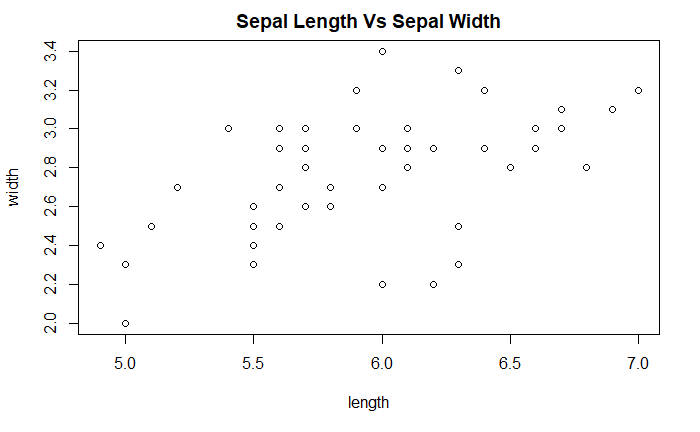

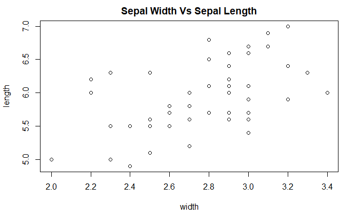

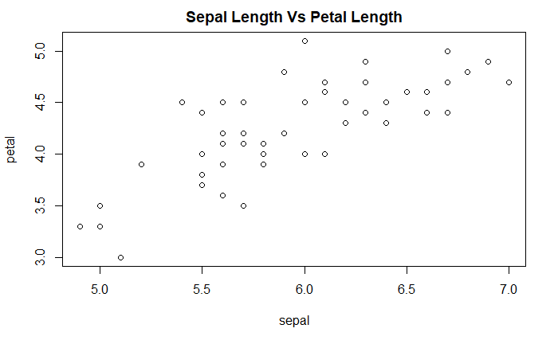

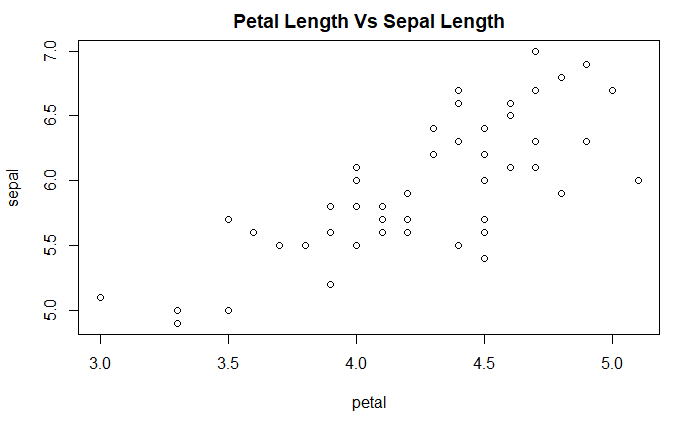

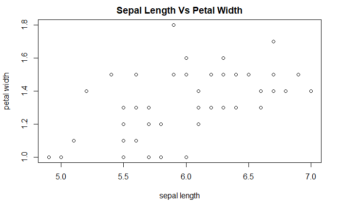

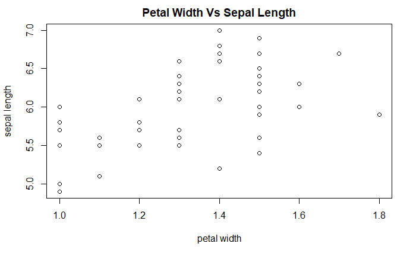

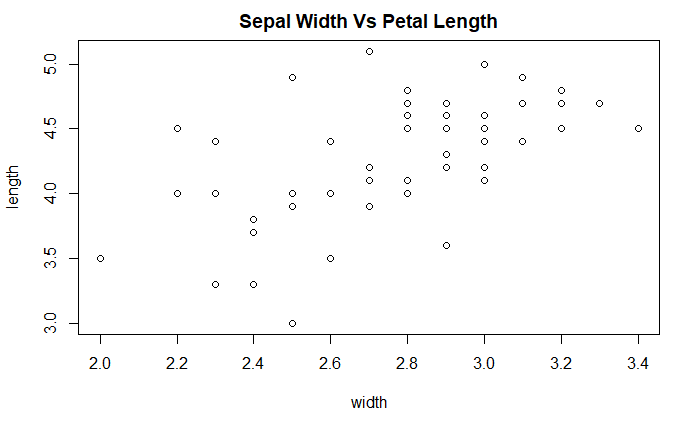

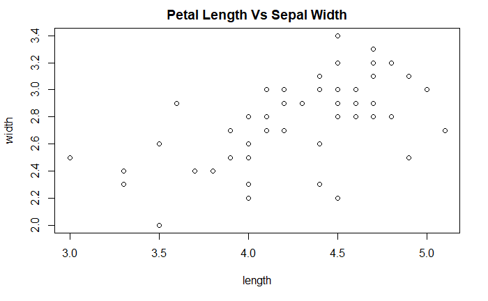

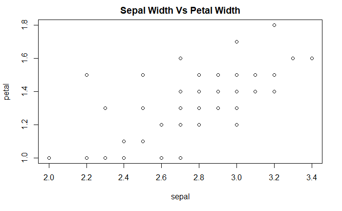

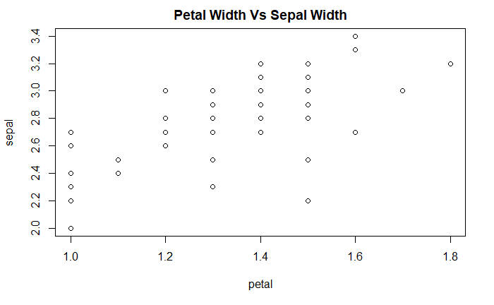

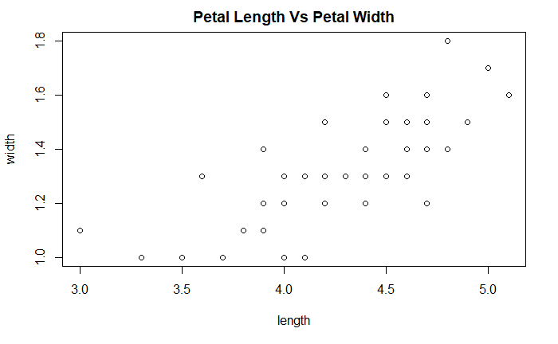

```
character(0)
```

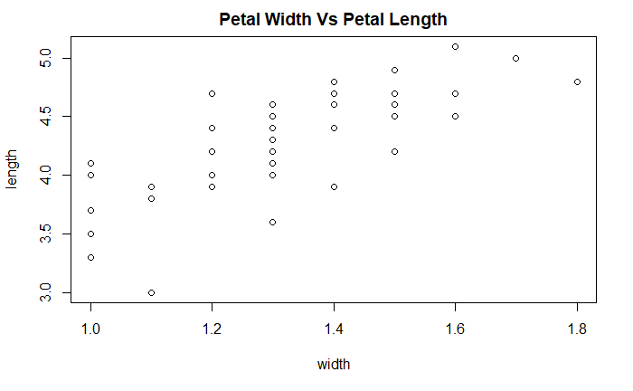

```r
# I don't know where character(0) is printing from so just ignore that. It shouldn't be there.
plots(versicolor)
```

##### b

```r
a <- x_dataframe(versicolor)
b <- y_dataframe(versicolor)
cor_coefs(a, b)
```

```
 [1] "Correlation for Sepal Length and Width = 0.804020053326707"
 [2] "Correlation for Sepal Width and Length = 0.804020053326707"
 [3] "Correlation for Sepal Length and Petal Length = 0.928444208466434"
 [4] "Correlation for Petal Length and Sepal Length = 0.928444208466434"
 [5] "Correlation for Sepal Length and Petal Width = 0.700688234967752"
 [6] "Correlation for Petal Width and Sepal Length = 0.700688234967752"
 [7] "Correlation for Sepal Width and Petal Length = 0.831023673913067"
 [8] "Correlation for Petal Length and Sepal Width = 0.831023673913067"
 [9] "Correlation for Sepal Width and Petal Width = 0.83939248902494"
[10] "Correlation for Petal Width and Sepal Width = 0.83939248902494"
[11] "Correlation for Petal Length and Width = 0.809088750391699"
[12] "Correlation for Petal Width and Length = 0.809088750391699"
```

##### c

```r
# Pair 1
# Petal Length Vs Sepal Length
values(versicolor$Petal.Length, versicolor$Sepal.Length)
```

```
[1] "Model Parameter for beta1 = 0.82828096118299"
[1] "Model Parameter for beta0 = 2.40752310536046"
[1] "Line of Best Fit: y = 2.40752310536046 + 0.82828096118299*x"
[1] "Coefficient of Determination = 0.999999999999991"
[1] "Standard Error of the Slope Parameter = 1.14752253226144e-08"
```

```r
# Pair 2
# Sepal Width Vs Petal Width
values(versicolor$Sepal.Width, versicolor$Petal.Width)
```

```
[1] "Model Parameter for beta1 = 0.418445595854919"
[1] "Model Parameter for beta0 = 0.166905699481873"
[1] "Line of Best Fit: y = 0.166905699481873 + 0.418445595854919*x"
[1] "Coefficient of Determination = 0.999999999999987"
[1] "Standard Error of the Slope Parameter = 6.92366166658071e-09"
```

```r
# Pair 3
# Sepal Width Vs Petal Length
values(versicolor$Sepal.Width, versicolor$Petal.Length)
```

```
[1] "Model Parameter for beta1 = 0.839378238341952"
[1] "Model Parameter for beta0 = 1.93492227979279"
[1] "Line of Best Fit: y = 1.93492227979279 + 0.839378238341952*x"
[1] "Coefficient of Determination = 0.999999999999995"
[1] "Standard Error of the Slope Parameter = 8.75781624591694e-09"
```